# Opponent tendency report

Minnesota Vikings offense Scouting report for the 49ers · 2026 Week 11 · Vikings at 49ers, Sun Nov 22, 2026 Line: SF -3.5 · O/U 46.5 · Model estimate (Elo v1 (cloud)): SF 53% to win (market 61%). Not betting advice. Data through Week 10 (9 games). Only games before this week are used. Ranks are among all 32 teams.

### Roster changes: MIN added QB Kirk Cousins; SF added WR Keenan Allen, added DT DeForest Buckner

| Date | Team | Player | Move | Before the move | Games since |
| --- | --- | --- | --- | --- | --- |
| Nov 10 | SF in | ⚠ WR Keenan Allen | from IND | 58% of IND off. snaps, 8 games, 20% of targets | 1 of 9 |
| Nov 10 | MIN in | ⚠ QB Kirk Cousins | from LV | 98% of LV off. snaps, 9 games, 97% of dropbacks | 1 of 9 |
| Oct 27 | SF in | ⚠ DT DeForest Buckner | from IND | 83% of IND def. snaps, 7 games | 2 of 9 |
| Sep 28 | MIN out | QB J.J. McCarthy | to NYG | no snaps for MIN | 6 of 9 |

⚠ MIN’s numbers below cover 9 games, 8 before Kirk Cousins arrived. The last-4 column has 1 after.

nflverse’s trade feed has nothing after Aug 28, 2025; newer trades come from the hand-kept list and weekly rosters.

### 3 things to know

1. **Red zone:** the NFL’s least efficient offense, -0.25 EPA per play (league avg +0.05). 46 plays
2. **3rd & 7+:** 2nd-most pass-heavy vs. expected, +6 pts pass rate over expected. 57 plays
3. **Early downs:** 3rd-least efficient offense, -0.10 EPA per play (league avg +0.01). 349 plays

### Early downs: close to the league’s expected pass rate

| Metric | Value | NFL rank | League avg | Last season | Plays |
| --- | --- | --- | --- | --- | --- |
| Pass rate | 51% | 28th | 55% | 55% (14th) | 349 |
| Pass rate over expected | -3 pts | 23rd | -1 pts | -2 pts (17th) | 349 |
| Shotgun rate | 52% | 20th | 55% | 47% (27th) | 349 |
| EPA per play | -0.10 | 30th | +0.01 | -0.04 (27th) | 349 |

### 3rd & 7+: they throw 98% of the time (league 94%, 3rd-most pass-heavy)

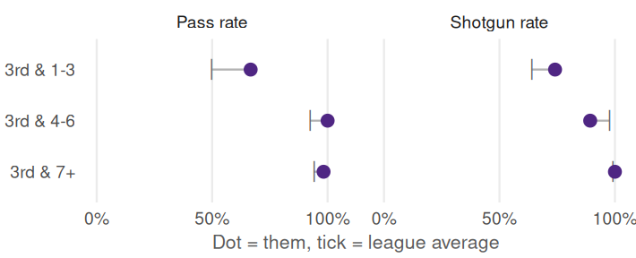

| Distance | Pass rate | EPA/play | Plays |
| --- | --- | --- | --- |
| 3rd & 1-3 | 67% (2nd) | -0.21 (28th) | 27* |
| 3rd & 4-6 | 100% (1st) | -0.03 (21st) | 28* |
| 3rd & 7+ | 98% (3rd) | -0.10 (18th) | 57 |

### Red zone: throw-first (65% pass rate)

| Metric | Value | NFL rank | League avg | Last season | Plays |
| --- | --- | --- | --- | --- | --- |
| Pass rate | 65% | 3rd | 53% | 63% (2nd) | 46 |
| Pass rate over expected | +10 pts | 3rd | -2 pts | +1 pts (6th) | 46 |
| EPA per play | -0.25 | 32nd | +0.05 | -0.11 (25th) | 46 |

### Tendency shifts: no big changes in the last 4 games

| Situation | Metric | Season | Last 4 | Change | Plays (last 4) |
| --- | --- | --- | --- | --- | --- |
| Early downs | Pass rate over expected | -3 pts | +1 pts | +4 pts | 142 |
| Early downs | Shotgun rate | 52% | 50% | -2 pts | 142 |
| Early downs | EPA per play | -0.10 | -0.12 | -0.02 | 142 |
| 3rd & 1-3 | Pass rate | 67% | 75% | +8 pts | 8* |
| Red zone | Pass rate | 65% | 75% | +10 pts | 16* |
| All neutral downs | EPA per play | -0.10 | -0.13 | -0.03 | 184 |

### Most dangerous: passes on 3rd & 7+ (-0.09 EPA per play vs. -0.07 league)

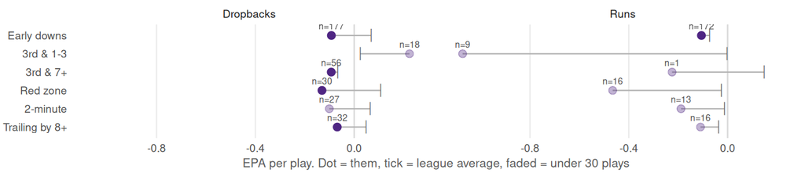

**How to read this.** Pass rate counts sacks and scrambles as passes. *Pass rate over expected* compares their pass rate with what an average team calls in the same down, distance, field position, score and time (nflverse `xpass` model). EPA = expected points added; above 0 is good for the offense. Early downs, 3rd down, red zone and “all neutral” use only plays when the offense’s win probability was 5–95%. The 2-minute and trailing-by-8+ splits use every play. Numbers marked * are under 30 plays: treat them as a hint, not a tendency. Shift = last 4 games differ from the season by 5+ points (0.10 EPA) on 30+ plays. Roster changes lists in-season trades (nflverse trade feed plus a hand-kept list) and other moves seen in weekly rosters; a regular (starting QB, 15%+ of targets, 30%+ of carries, or 60%+ of snaps before the move) is marked ⚠. Data: nflverse play-by-play (nflfastR / nflreadr), openly licensed. Built by Chris Antosiewicz · [source](https://github.com/chrisantosiewicz/nfl-opponent-report).